# Forecasting with Two-Way ANOVA in R - When interaction is present

Anita Owens

## 1. Set up environment

```r
# Install pacman if needed
if (!require("pacman")) install.packages("pacman")
# load packages
pacman::p_load(pacman,
  tidyverse, openxlsx, ggpubr)
```

## 2. Import data

```r
#Dataset is in subfolder
(games <- read.xlsx("datasets/games.xlsx", sheet = 3))
```

|  | Advertising | PriceLow | PriceMedium | PriceHigh |
| --- | --- | --- | --- | --- |
| 1 | Low | 41 | 21 | 15 |
| 2 | Low | 25 | 20 | 14 |
| 3 | Low | 23 | 16 | 13 |
| 4 | Medium | 28 | 28 | 14 |
| 5 | Medium | 30 | 22 | 13 |
| 6 | Medium | 32 | 18 | 12 |
| 7 | High | 50 | 34 | 13 |
| 8 | High | 51 | 40 | 13 |
| 9 | High | 52 | 32 | 13 |

```r
(games_long <- games %>%
  pivot_longer(cols = starts_with("Price"), #columns to pivot to rows
               names_to = "price", #name the new column for the price variable
               values_to = "sales")) #the new sales column
```

| Advertising | price | sales |
| --- | --- | --- |
| Low | PriceLow | 41 |
| Low | PriceMedium | 21 |
| Low | PriceHigh | 15 |
| Low | PriceLow | 25 |
| Low | PriceMedium | 20 |
| Low | PriceHigh | 14 |
| Low | PriceLow | 23 |
| Low | PriceMedium | 16 |
| Low | PriceHigh | 13 |
| Medium | PriceLow | 28 |

[output cut: 17 more lines]

```r
games_long <- games_long %>%
  mutate(advertising = factor(Advertising, levels = c("Low", "Medium", "High")),
  price = factor(price, levels = c("PriceLow", "PriceMedium", "PriceHigh"))) %>%
  select(-Advertising)

str(games_long)
```

```
## tibble [27 × 3] (S3: tbl_df/tbl/data.frame)
##  $ price      : Factor w/ 3 levels "PriceLow","PriceMedium",..: 1 2 3 1 2 3 1 2 3 1 ...
##  $ sales      : num [1:27] 41 21 15 25 20 14 23 16 13 28 ...
##  $ advertising: Factor w/ 3 levels "Low","Medium",..: 1 1 1 1 1 1 1 1 1 2 ...
```

## 3. Visualize Data

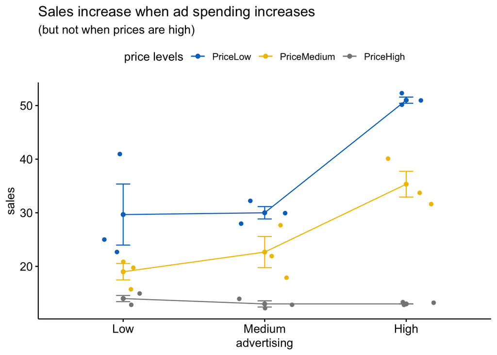

```r
#Plot using ggpubr
ggline(games_long, x = "advertising", y = "sales",
       add = c("mean_se", "jitter"),
       color = "price", palette = "jco",
       title = "Sales increase when ad spending increases",
       subtitle = "(but not when prices are high)",
       legend.title = "price levels"
       )
```

## 4. Two-way ANOVA model

The aov function models each combination of advertising and price on sales.

The f-values and p-values suggests that we reject the null hypothesis for advertising, price, and the interaction between advertising and price.

```r
two_way_aov <- aov(sales ~ advertising*price, data = games_long)

#The anova table
summary(two_way_aov)
```

```
##                   Df Sum Sq Mean Sq F value   Pr(>F)
## advertising        2  829.0   414.5   24.22 7.86e-06 ***
## price              2 2498.7  1249.4   73.02 2.31e-09 ***
## advertising:price  4  509.9   127.5    7.45  0.00101 **
## Residuals         18  308.0    17.1
## ---
## Signif. codes:  0 '***' 0.001 '**' 0.01 '*' 0.05 '.' 0.1 ' ' 1
```

How do we use this information from the aov table to forecast?

Since the p-value for the interaction (advertising*price) is very small, we can forecast sales for any price and advertising combination equal to the mean of the observations.

## 5. Model Diagnostics

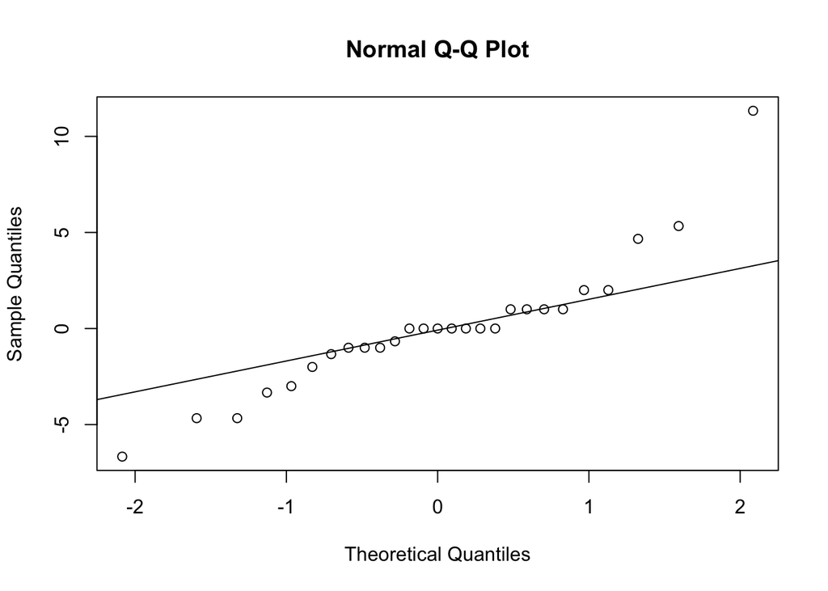

```r
#histogram with kernel density line
#hist(two_way_aov$residuals, prob = TRUE)
#lines(density(two_way_aov$residuals))

#However, when you have a small dataset it's better to visualize the residuals using qqplot.
qqnorm(two_way_aov$residuals)
qqline(two_way_aov$residuals)
```

```r
#We have a few points quite far away from the line
```

## 6. Sales Forecast Table

```r
(forecast_tab <- games_long %>%
  group_by(advertising, price) %>%
  summarize(forecast_sales = round(mean(sales),2),
            std_dev = round(sd(sales),2)))
```

| advertising | price | forecast_sales | std_dev |
| --- | --- | --- | --- |
| Low | PriceLow | 29.67 | 9.87 |
| Low | PriceMedium | 19.00 | 2.65 |
| Low | PriceHigh | 14.00 | 1.00 |
| Medium | PriceLow | 30.00 | 2.00 |
| Medium | PriceMedium | 22.67 | 5.03 |
| Medium | PriceHigh | 13.00 | 1.00 |
| High | PriceLow | 51.00 | 1.00 |
| High | PriceMedium | 35.33 | 4.16 |
| High | PriceHigh | 13.00 | 0.00 |

Because the p-value for the interaction is low, we have a significant interaction between advertising and price. Forecast if advertising is high and price is medium is 35.33

## 7. Final Summary

A key insight for marketing stakeholders, would be to cut back on advertising when the price is high.

Two-way ANOVA (with replication), if interaction effect **is significant**, then the predicted value is the value of the response variable (y) is equal to the mean of all observations having that combination of factor levels.